# Tugas 1 — Pengantar Analisis Data Kategori

Latihan Analisis Data dengan R dan Quarto

Mahasiswa

Rahmawati

NIM

241061003

Kode Tugas

ADK1-070181AE

**Tujuan tugas.** Gunakan kembali konsep dan fungsi R yang telah dibahas pada Pertemuan 1 untuk mengenali struktur data kategori, membuat ringkasan deskriptif, memvisualisasikan data, dan menjelaskan insight secara hati-hati.

**CatatanPola kerja**

Ikuti pola kelas: **predict → run → inspect → explain**.

Pada setiap bagian diberikan **sedikit petunjuk kode**.  
Jika diminta menjelaskan atau menuliskan interpretasi, gunakan kotak **Jawaban Anda** yang telah disediakan.

# 1 1. Mengenali Data

Gunakan R untuk melihat beberapa baris awal, struktur data, dan nama variabel.

**TipPetunjuk kode**

```r
head(...)
str(...)
names(...)
```

Ganti `...` dengan objek data yang digunakan.

```r
#
head(data_tugas1_241061003)
```

```
# A tibble: 6 × 9
  RecordID ProgramStudi     Gender DeviceUtama ModaBelajar Kepuasan
     <dbl> <chr>            <chr>  <chr>       <chr>       <chr>
1   493003 Sistem Informasi L      Smartphone  Diskusi     Cukup
2   130048 Matematika       L      Tablet      Praktik     Tidak Puas
3   397022 Matematika       P      Laptop      Praktik     Puas
4   753034 Matematika       L      Smartphone  Diskusi     Puas
5   193989 Sains Data       P      Laptop      Video       Puas
6   324820 Sains Aktuaria   P      Laptop      Diskusi     Puas
# ℹ 3 more variables: IntensitasBelajar <chr>, DurasiBelajarJam <dbl>,
#   PaketID <chr>
```

```r
str(data_tugas1_241061003)
```

```
spc_tbl_ [100 × 9] (S3: spec_tbl_df/tbl_df/tbl/data.frame)
 $ RecordID         : num [1:100] 493003 130048 397022 753034 193989 ...
 $ ProgramStudi     : chr [1:100] "Sistem Informasi" "Matematika" "Matematika" "Matematika" ...
 $ Gender           : chr [1:100] "L" "L" "P" "L" ...
 $ DeviceUtama      : chr [1:100] "Smartphone" "Tablet" "Laptop" "Smartphone" ...
 $ ModaBelajar      : chr [1:100] "Diskusi" "Praktik" "Praktik" "Diskusi" ...
 $ Kepuasan         : chr [1:100] "Cukup" "Tidak Puas" "Puas" "Puas" ...
 $ IntensitasBelajar: chr [1:100] "Sedang" "Sedang" "Tinggi" "Tinggi" ...
 $ DurasiBelajarJam : num [1:100] 8.9 4.5 11.9 11.5 8.4 10.6 11 5.3 10.5 1.8 ...
 $ PaketID          : chr [1:100] "ADK1-070181AE" "ADK1-070181AE" "ADK1-070181AE" "ADK1-070181AE" ...
 - attr(*, "spec")=
  .. cols(
  ..   RecordID = col_double(),
  ..   ProgramStudi = col_character(),
  ..   Gender = col_character(),
  ..   DeviceUtama = col_character(),
  ..   ModaBelajar = col_character(),
  ..   Kepuasan = col_character(),
  ..   IntensitasBelajar = col_character(),
  ..   DurasiBelajarJam = col_double(),
  ..   PaketID = col_character()
  .. )
 - attr(*, "problems")=<pointer: 0x000001ae90cffb00>
```

```r
names(data_tugas1_241061003)
```

```
[1] "RecordID"          "ProgramStudi"      "Gender"
[4] "DeviceUtama"       "ModaBelajar"       "Kepuasan"
[7] "IntensitasBelajar" "DurasiBelajarJam"  "PaketID"
```

Lengkapi tabel berikut.

| Variabel | Jenis Variabel | Alasan Singkat |
| --- | --- | --- |
| RecordID | Identifier | Angka unik per responden, hanya penanda baris, tidak dianalisis sebagai nilai |
| ProgramStudi | Nominal | Kategori nama program studi (Sistem Informasi, Matematika, Sains Data, Sains Aktuaria), tidak punya urutan |
| Gender | Nominal | Kategori L/P, tidak punya urutan tingkatan |
| DeviceUtama | Nominal | Kategori perangkat (Smartphone, Tablet, Laptop), tidak punya urutan alami |
| ModaBelajar | Nominal | Kategori cara belajar (Diskusi, Praktik, Video, Buku), tidak punya urutan alami |
| Kepuasan | Ordinal | Punya tingkatan jelas: Tidak Puas < Cukup < Puas < Sangat Puas |
| IntensitasBelajar | Ordinal | Punya tingkatan: Rendah < Sedang < Tinggi |
| DurasiBelajarJam | Numerik (rasio) | Berupa angka jam belajar (desimal), bisa dijumlah/dirata-ratakan secara bermakna |
| PaketID | Identifier | Kode paket tugas (sama untuk semua baris), bukan variabel analisis |

Jawab singkat:

1. Variabel mana yang merupakan identifier?
2. Variabel mana yang bersifat ordinal?
3. Mengapa kode angka belum tentu berarti data numerik?

**Jawaban Anda**

1. `RecordID` (dan `PaketID`) merupakan identifier karena hanya berfungsi sebagai penanda unik/label administratif tiap responden, bukan variabel yang dianalisis.
2. `Kepuasan` dan `IntensitasBelajar` bersifat ordinal karena kategorinya memiliki urutan tingkatan yang bermakna (Tidak Puas < Cukup < Puas < Sangat Puas; Rendah < Sedang < Tinggi).
3. Kode angka pada data kategori (mis. `RecordID` yang berupa deretan angka) hanya berfungsi sebagai label/identitas, bukan besaran matematis. Jika angka semacam itu dijumlahkan atau dirata-ratakan, hasilnya tidak punya arti karena angkanya tidak merepresentasikan kuantitas, hanya penanda.

# 2 2. Menyiapkan Data Kategori

Variabel latihan Anda:

```r
cat("Nominal :", identitas$nominal_utama[1], "\n")
```

```
Nominal : Gender
```

```r
cat("Ordinal :", identitas$ordinal_utama[1], "\n")
```

```
Ordinal : Kepuasan
```

```r
cat("Urutan  :", identitas$urutan_ordinal[1], "\n")
```

```
Urutan  : Tidak Puas|Cukup|Puas|Sangat Puas
```

Lakukan hal berikut:

1. ubah variabel nominal menjadi factor;
2. ubah variabel ordinal menjadi ordered factor;
3. periksa level kategorinya.

**TipPetunjuk kode**

Untuk nominal:

```r
factor(...)
levels(...)
```

Untuk ordinal:

```r
factor(..., levels = ..., ordered = TRUE)
```

```r
nominal_var <- identitas$nominal_utama[1]
ordinal_var <- identitas$ordinal_utama[1]
urutan <- strsplit(identitas$urutan_ordinal[1], "\\|")[[1]]

# Tulis kode Anda di bawah ini

# 1. Mengubah variabel nominal menjadi factor
data_tugas1_241061003[[nominal_var]] <- factor(
  data_tugas1_241061003[[nominal_var]]
)

# 2. Mengubah variabel ordinal menjadi ordered factor
data_tugas1_241061003[[ordinal_var]] <- factor(
  data_tugas1_241061003[[ordinal_var]],
  levels = urutan,
  ordered = TRUE
)

# 3. Memeriksa level kategori
levels(data_tugas1_241061003[[nominal_var]])
```

```
[1] "L" "P"
```

```r
levels(data_tugas1_241061003[[ordinal_var]])
```

```
[1] "Tidak Puas"  "Cukup"       "Puas"        "Sangat Puas"
```

Tuliskan satu kalimat: **mengapa urutan level ordinal perlu ditetapkan dengan benar?**

**Jawaban Anda**

Urutan level ordinal perlu ditetapkan dengan benar agar R dapat membandingkan kategori secara logis (mis. “Puas” > “Cukup”), sehingga hasil pengurutan, perbandingan, dan visualisasi mencerminkan tingkatan yang sesungguhnya, bukan urutan alfabet atau urutan kemunculan data

# 3 3. Quality Control Awal

Lakukan pemeriksaan sederhana terhadap:

- struktur data;
- level/kategori;
- missing value;
- konsistensi penulisan kategori.

**TipPetunjuk kode**

Beberapa pola fungsi yang dapat digunakan:

```r
str(...)
levels(...)
unique(...)
is.na(...)
colSums(...)
```

Pilih fungsi yang sesuai dengan tujuan pemeriksaan Anda.

```r
# Struktur data
str(data_tugas1_241061003)
```

```
spc_tbl_ [100 × 9] (S3: spec_tbl_df/tbl_df/tbl/data.frame)
 $ RecordID         : num [1:100] 493003 130048 397022 753034 193989 ...
 $ ProgramStudi     : chr [1:100] "Sistem Informasi" "Matematika" "Matematika" "Matematika" ...
 $ Gender           : Factor w/ 2 levels "L","P": 1 1 2 1 2 2 2 1 1 1 ...
 $ DeviceUtama      : chr [1:100] "Smartphone" "Tablet" "Laptop" "Smartphone" ...
 $ ModaBelajar      : chr [1:100] "Diskusi" "Praktik" "Praktik" "Diskusi" ...
 $ Kepuasan         : Ord.factor w/ 4 levels "Tidak Puas"<"Cukup"<..: 2 1 3 3 3 3 2 3 2 2 ...
 $ IntensitasBelajar: chr [1:100] "Sedang" "Sedang" "Tinggi" "Tinggi" ...
 $ DurasiBelajarJam : num [1:100] 8.9 4.5 11.9 11.5 8.4 10.6 11 5.3 10.5 1.8 ...
 $ PaketID          : chr [1:100] "ADK1-070181AE" "ADK1-070181AE" "ADK1-070181AE" "ADK1-070181AE" ...
 - attr(*, "spec")=
  .. cols(
  ..   RecordID = col_double(),
  ..   ProgramStudi = col_character(),
  ..   Gender = col_character(),
  ..   DeviceUtama = col_character(),
  ..   ModaBelajar = col_character(),
  ..   Kepuasan = col_character(),
  ..   IntensitasBelajar = col_character(),
  ..   DurasiBelajarJam = col_double(),
  ..   PaketID = col_character()
  .. )
 - attr(*, "problems")=<pointer: 0x000001ae90cffb00>
```

```r
# Level/kategori variabel nominal dan ordinal
levels(data_tugas1_241061003[[nominal_var]])
```

```
[1] "L" "P"
```

```r
levels(data_tugas1_241061003[[ordinal_var]])
```

```
[1] "Tidak Puas"  "Cukup"       "Puas"        "Sangat Puas"
```

```r
# Kategori unik
unique(data_tugas1_241061003[[nominal_var]])
```

```
[1] L P
Levels: L P
```

```r
unique(data_tugas1_241061003[[ordinal_var]])
```

```
[1] Cukup       Tidak Puas  Puas        Sangat Puas <NA>
Levels: Tidak Puas < Cukup < Puas < Sangat Puas
```

```r
# Missing value setiap kolom
colSums(is.na(data_tugas1_241061003))
```

```
         RecordID      ProgramStudi            Gender       DeviceUtama
                0                 0                 0                 0
      ModaBelajar          Kepuasan IntensitasBelajar  DurasiBelajarJam
                0                 2                 0                 1
          PaketID
                0
```

Tuliskan **dua temuan singkat** dari pemeriksaan tersebut.

**Jawaban Anda**

1. Variabel nominal memiliki dua kategori, yaitu **L** dan **P**, sedangkan variabel ordinal memiliki empat kategori dengan urutan **Tidak Puas < Cukup < Puas < Sangat Puas**. Hasil pemeriksaan menunjukkan bahwa kategori pada kedua variabel telah tersimpan sesuai tipe kategorinya.
2. Terdapat **3 missing value** pada dataset, yaitu **2 missing value pada variabel Kepuasan** dan **1 missing value pada variabel DurasiBelajarJam**. Pada variabel ordinal juga terlihat adanya nilai `NA` pada hasil pemeriksaan kategori unik, yang menunjukkan adanya data kepuasan yang kosong.

# 4 4. Frekuensi dan Proporsi

Sebelum menjalankan kode, prediksi:

> Menurut Anda, kategori mana yang paling banyak muncul pada variabel nominal Anda?

**Prediksi Anda**

Saya memprediksi bahwa kategori **L** akan menjadi kategori yang paling banyak muncul pada variabel nominal.

Setelah itu, buat:

- tabel frekuensi untuk variabel nominal;
- proporsi untuk variabel ordinal.

**TipPetunjuk kode**

```r
table(...)
prop.table(...)
```

Anda dapat menyimpan hasil `table()` ke sebuah objek terlebih dahulu sebelum menghitung proporsi.

```r
# Tabel frekuensi variabel nominal
freq_nominal <- table(data_tugas1_241061003[[nominal_var]])
freq_nominal
```

```
 L  P
51 49
```

```r
# Proporsi variabel ordinal
prop_ordinal <- prop.table(
  table(data_tugas1_241061003[[ordinal_var]])
)
prop_ordinal * 100
```

```
 Tidak Puas       Cukup        Puas Sangat Puas
   10.20408    23.46939    33.67347    32.65306
```

Tuliskan **dua kalimat insight** berdasarkan output.

**Interpretasi Anda**

1. Kategori **L** merupakan kategori yang paling banyak muncul pada variabel nominal dengan frekuensi **51 data (51%)**, sedangkan kategori P sebanyak **49 data (49%)**.
2. Pada variabel ordinal, kategori **Puas** memiliki proporsi paling tinggi yaitu **33,67%**, diikuti oleh **Sangat Puas sebesar 32,65%**, **Cukup sebesar 23,47%**, dan **Tidak Puas sebesar 10,20%**.

# 5 5. Tabel Silang

Pasangan variabel Anda:

```r
x <- identitas$tab_baris[1]
y <- identitas$tab_kolom[1]

cat("Baris :", x, "\n")
```

```
Baris : Gender
```

```r
cat("Kolom :", y, "\n")
```

```
Kolom : ModaBelajar
```

Buat tabel silang untuk kedua variabel tersebut.

Jika diperlukan, tampilkan proporsi per baris untuk membantu membaca pola.

**TipPetunjuk kode**

```r
table(..., ...)
prop.table(..., margin = 1)
```

Lengkapi sendiri objek yang diperlukan.

```r
# # Menentukan variabel tabel silang
x <- identitas$tab_baris[1]
y <- identitas$tab_kolom[1]

cat("Baris :", x, "\n")
```

```
Baris : Gender
```

```r
cat("Kolom :", y, "\n")
```

```
Kolom : ModaBelajar
```

```r
# Membuat tabel silang
tab_silang <- table(
  data_tugas1_241061003[[x]],
  data_tugas1_241061003[[y]]
)

# Menampilkan tabel frekuensi
tab_silang
```

```
    Buku Diskusi Praktik Video
  L    5      15      19    12
  P   12      11      10    16
```

```r
# Menampilkan proporsi per baris
proporsi_baris <- prop.table(tab_silang, margin = 1)
round(proporsi_baris * 100, 2)
```

```
     Buku Diskusi Praktik Video
  L  9.80   29.41   37.25 23.53
  P 24.49   22.45   20.41 32.65
```

Tuliskan **satu kalimat** yang menjelaskan pola yang tampak.

**Interpretasi Anda**

Pada kategori **L**, moda belajar yang paling banyak digunakan adalah **Praktik sebesar 37,25%**, sedangkan pada kategori **P**, moda belajar yang paling banyak digunakan adalah **Video sebesar 32,65%**

**Penting**

Gunakan bahasa deskriptif. Jangan langsung menyimpulkan adanya hubungan signifikan atau sebab-akibat.

# 6 6. Visualisasi Kategorik

Variabel yang divisualisasikan:

```r
v <- identitas$visualisasi[1]
cat("Variabel grafik :", v, "\n")
```

```
Variabel grafik : Gender
```

Buat **satu grafik batang** seperti yang telah dipelajari pada Pertemuan 1.

**TipPetunjuk kode**

```r
library(ggplot2)

ggplot(..., aes(x = ...)) +
  geom_bar() +
  labs(...)
```

Sesuaikan objek data, variabel, judul, dan label sumbu.

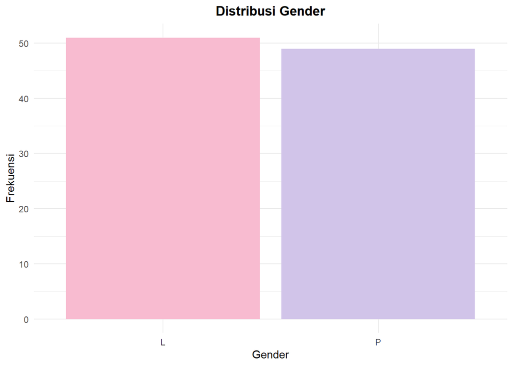

```r
v <- identitas$visualisasi[1]

library(ggplot2)

ggplot(data_tugas1_241061003, aes(x = .data[[v]], fill = .data[[v]])) +
  geom_bar() +
  scale_fill_manual(values = c("#F8BBD0", "#D1C4E9")) +
  labs(
    title = paste("Distribusi", v),
    x = v,
    y = "Frekuensi"
  ) +
  theme_minimal() +
  theme(
    plot.title = element_text(hjust = 0.5, face = "bold"),
    legend.position = "none"
  )
```

Tuliskan **satu kalimat** interpretasi grafik.

**Interpretasi Anda**

Grafik menunjukkan bahwa kategori **L** memiliki frekuensi lebih tinggi dibandingkan kategori **P** pada variabel Gender. Kategori L berjumlah **51 data**, sedangkan kategori P berjumlah **49 data**.

Grafik menunjukkan bahwa kategori L memiliki frekuensi paling tinggi dibandingkan kategori lainnya pada variabel Gender.

# 7 7. Kesimpulan

Tuliskan **3 poin kesimpulan singkat** berdasarkan hasil analisis.

Setiap kesimpulan harus:

- didukung oleh output yang telah Anda hasilkan;
- menggunakan angka yang relevan;
- ditulis dengan bahasa Anda sendiri;
- tidak menggunakan klaim sebab-akibat.

**Kesimpulan Anda**

1. Berdasarkan analisis Gender, kategori **L** memiliki frekuensi sebanyak **51 data (51%)**, sedangkan kategori **P** sebanyak **49 data (49%)**.
2. Pada variabel Kepuasan, kategori **Puas** memiliki proporsi tertinggi yaitu **33,67%**, diikuti kategori **Sangat Puas sebesar 32,65%**, **Cukup sebesar 23,47%**, dan **Tidak Puas sebesar 10,20%**.
3. Berdasarkan tabel silang Gender dan ModaBelajar, kategori **L** paling banyak menggunakan **Praktik sebesar 37,25%**, sedangkan kategori **P** paling banyak menggunakan **Video sebesar 32,65%**.

**Analisis Data Kategori — Tugas 1**  
Predict → Run → Inspect → Explain